# **Analysis of Salaries in the Data Science Field**

### Group Members: Dior Diarra Seck, Khar Aminata Cassé

#### Fall 2023

## **1. Required Tools**

You will need Python 3.10 and these libraries:

- Pandas
- Numpy
- Matplotlib
- Sklearn
- Seaborn
- Statsmodels
- Plotly

Our graphs are mostly created with both matplotlib and seaborn. We also use numpy and pandas throughout this tutorial. Statsmodels is needed when doing the regression analysis in the end.

If you are working in a group, we suggest using google colab as your editor, which is what we have done here. Jupyter notebooks is great, but if you want to work on the code on different devices, colab is the way to go.

```python
import numpy as np
import pandas as pd
from sklearn import linear_model
import matplotlib.pyplot as plt
import seaborn as sns
import statsmodels.api as sum
import statsmodels.formula.api as smf
import sqlite3
from ggplot import *
```

# **2. Introduction: The Importance of the Data Science Industry**

1. There’s a low supply of workers in the data science field: Many data science positions are available, but there are very few people with the skills required to fill these roles. This means if you have storytelling, quantitative and computational data skills and can communicate effectively and act ethically, you’ll have a competitive edge in securing a job in data science.
2. The data science field is versatile and broadly applicable: Data science is a very flexible field and can be applied across all types of industries. From banking and education to marketing and nonprofits, nearly every type of organization benefits from having a data science expert on their team who can explore, report on, and monitor data to make better decisions, improve performance, and meet goals faster. So, if you’re wondering what you can do with a data science degree in a specific industry, it’s likely you’ll find an opportunity that resonates with your career interests and values.
3. A data science career has the potential to make a lasting impact: As a data scientist, you’ll compile, analyze, and extract valuable insights from data. That data has the ability to do many powerful things: detect early-stage tumors, optimize shipping routes, improve athletic performance, and detect fraud, for starters.

## **3. Why Data Science?**

According to glassdoor in 2023, out of the 50 best occupations in the United States, Data Science falls at #3 .

Data Scientists made a median salary of 100,910 US Dollars in 2021. The highest paid 25% made 130,770 US Dollars that year, while the lowest-paid 25% made 77,620 US Dollars.

## **4. Goals with this Analysis**

After reading several articles about the data science industry, seeing how the job market is looking for more and more employees to fill data science role and how universities are incorporating data science majors as minor, concentrations, and even actual majors for undergraduates. The University of Notre Dame is an example of this. We decided to see if the salaries are reflecting this need for data science roles. Our analysis will mostly be comprised of multiple graphs to visualize how certain features such as size company, location ... affect the salary of the most popular roles within the data science industry.

## **5. About the Data**

The first step in this analysis is to choose a data set. After looking over several data sets, we chose this one: [Data Science Salaries 2023](https://www.kaggle.com/datasets/arnabchaki/data-science-salaries-2023?resource=download). This data seemed perfect for this, it had many different feature values such as work year, experience level, company size, company location, salary in usd, etc. We had a lot of things to work with and thus could compare data science salaries in a particular year in relation to company size, for example. The data set also wasn't perfect, so we were able to clean the data before using it.

## **6. DATA COLLECTION - Scraping**

The dataset that we chose already came in the form of a .csv file, so we were able to use pandas' read csv method to get our data set in the form of a DataFrame, which is what we have shown below. The current data frame that we have has a few things that we want to change, which we will accomplish in our data cleaning step.

```python
data = pd.read_csv('ds_salaries.csv')
data.head(5)
```

|  | work_year | experience_level | employment_type | job_title | salary | salary_currency | salary_in_usd | employee_residence | remote_ratio | company_location | company_size |
| --- | --- | --- | --- | --- | --- | --- | --- | --- | --- | --- | --- |
| 0 | 2023 | SE | FT | Principal Data Scientist | 80000 | EUR | 85847 | ES | 100 | ES | L |
| 1 | 2023 | MI | CT | ML Engineer | 30000 | USD | 30000 | US | 100 | US | S |
| 2 | 2023 | MI | CT | ML Engineer | 25500 | USD | 25500 | US | 100 | US | S |
| 3 | 2023 | SE | FT | Data Scientist | 175000 | USD | 175000 | CA | 100 | CA | M |
| 4 | 2023 | SE | FT | Data Scientist | 120000 | USD | 120000 | CA | 100 | CA | M |

## **7. DATA PROCESSING: Cleaning**

Our data set is pretty big and filled with information and, as we learned in class, cleaning data is an important step (right after collecting the dat)a to make the optimal analysis and to make good predictions. Our step one when it came to cleaning the data was to get rid of duplicates. We decided to get rid of all the duplicates that were on the dataframe. One of the reasons why we decided to remove duplicates is because towards the end we will build a model using linear regression and having duplicates can and probably will add the weights of samples and can cause bias and because duplicates can also make training longer as they'd increase data size.

```python
# We are using the describe build-in function and transposing the dataframe in order to have a better look at our data
data.describe().transpose()
```

|  | count | mean | std | min | 25% | 50% | 75% | max |
| --- | --- | --- | --- | --- | --- | --- | --- | --- |
| work_year | 3755.0 | 2022.373635 | 0.691448 | 2020.0 | 2022.0 | 2022.0 | 2023.0 | 2023.0 |
| salary | 3755.0 | 190695.571771 | 671676.500508 | 6000.0 | 100000.0 | 138000.0 | 180000.0 | 30400000.0 |
| salary_in_usd | 3755.0 | 137570.389880 | 63055.625278 | 5132.0 | 95000.0 | 135000.0 | 175000.0 | 450000.0 |
| remote_ratio | 3755.0 | 46.271638 | 48.589050 | 0.0 | 0.0 | 0.0 | 100.0 | 100.0 |

```python
data = data.drop_duplicates(keep = 'first')
data.head(5)
```

|  | work_year | experience_level | employment_type | job_title | salary | salary_currency | salary_in_usd | employee_residence | remote_ratio | company_location | company_size |
| --- | --- | --- | --- | --- | --- | --- | --- | --- | --- | --- | --- |
| 0 | 2023 | SE | FT | Principal Data Scientist | 80000 | EUR | 85847 | ES | 100 | ES | L |
| 1 | 2023 | MI | CT | ML Engineer | 30000 | USD | 30000 | US | 100 | US | S |
| 2 | 2023 | MI | CT | ML Engineer | 25500 | USD | 25500 | US | 100 | US | S |
| 3 | 2023 | SE | FT | Data Scientist | 175000 | USD | 175000 | CA | 100 | CA | M |
| 4 | 2023 | SE | FT | Data Scientist | 120000 | USD | 120000 | CA | 100 | CA | M |

Our second step when it came to cleaning was to remove irrelevant data. We opted to remove the salary and the salary_currency columns because we already have a column named " salary_in_usd" which, in a way, standardized the data by making it simpler to process, analyze, and store since we will be looking at salary in USD accross all observations. The next data we decided to remove was the employee_residence, we also considered it as irrelevant data since it's the same information as company_location accross all the table.

```python
data1 = data.drop(columns = ['salary', 'salary_currency', 'employee_residence'])
```

```python
data1.head()
```

|  | work_year | experience_level | employment_type | job_title | salary_in_usd | remote_ratio | company_location | company_size |
| --- | --- | --- | --- | --- | --- | --- | --- | --- |
| 0 | 2023 | SE | FT | Principal Data Scientist | 85847 | 100 | ES | L |
| 1 | 2023 | MI | CT | ML Engineer | 30000 | 100 | US | S |
| 2 | 2023 | MI | CT | ML Engineer | 25500 | 100 | US | S |
| 3 | 2023 | SE | FT | Data Scientist | 175000 | 100 | CA | M |
| 4 | 2023 | SE | FT | Data Scientist | 120000 | 100 | CA | M |

```python
#set display options
pd.set_option('display.max_rows', 500)
pd.set_option('display.max_columns', 50)
```

Our third and final step for cleaning the data was to "detect outliers". As we previous said, we had more than 2000 observation in our data set, we noticed that if we wanted to make a good exploratory analysis we needed to group certain values together. We used the value_counts function to know exactly which data would make a bigger impact if we were to make plot to analyse the data. Certain coutries like the US, CA and IN had higher impacts than say IR, CR and MT. Once we posed that problem, we decided to collapse the coutries that had less than 10 count as other since they were not going to make a big change in our data and they would also overpopulate our graph/plots.

```python
data1['company_location'].value_counts()
```

```
company_location
US    1929
GB     155
CA      83
IN      57
DE      55
ES      44
FR      33
BR      15
AU      14
PT      14
NL      13
GR      11
MX      10
IE       7
SG       6
AT       6
JP       6
TR       5
CH       5
NG       5
PL       5
PK       4
LV       4
DK       4
IT       4
PR       4
SI       4
BE       4
CO       4
UA       4
HR       3
TH       3
RU       3
AR       3
CZ       3
AE       3
FI       3
AS       3
LU       3
```

[output cut: 19 more lines]

```
MY       1
AL       1
MA       1
PH       1
BO       1
VN       1
AM       1
BA       1
SK       1
MK       1
BS       1
IR       1
CR       1
MT       1
Name: count, dtype: int64
```

```python
#collapse countries with 10 or less records into an other category
categories_to_keep = ['US','GB', 'CA', 'IN', 'DE', 'ES', 'FR', 'BR','AU','PT','NL', 'GR','MX']
data1.loc[(~data1.company_location.isin(categories_to_keep)), 'company_location'] = 'OTHER'
```

```python
data1.head()
```

|  | work_year | experience_level | employment_type | job_title | salary_in_usd | remote_ratio | company_location | company_size |
| --- | --- | --- | --- | --- | --- | --- | --- | --- |
| 0 | 2023 | SE | FT | Principal Data Scientist | 85847 | 100 | ES | L |
| 1 | 2023 | MI | CT | ML Engineer | 30000 | 100 | US | S |
| 2 | 2023 | MI | CT | ML Engineer | 25500 | 100 | US | S |
| 3 | 2023 | SE | FT | Data Scientist | 175000 | 100 | CA | M |
| 4 | 2023 | SE | FT | Data Scientist | 120000 | 100 | CA | M |

## **8. EXPLORATORY DATA ANALYSIS**

Now that we have cleaned our data set to our liking, we can begin analyzing our data. In this step we will be creating several graphs to show how different feature values may affect salary in the data science field. We will be exploring our data quite a bit in this step.

## **8.1 Narrow Down Data**

Because of how large our dataset is, we have decided to narrow our analysis down to looking at the top 5 jobs in the dataset based on which ones make the most impact.

```python
allTimeTopFive = data1["job_title"].value_counts().nlargest(5).reset_index()
allTimeTopFive=  allTimeTopFive.rename(columns={"job_title": "index"})
topFivejobs = allTimeTopFive['index']
topFivejobs
```

```
0                Data Engineer
1               Data Scientist
2                 Data Analyst
3    Machine Learning Engineer
4           Analytics Engineer
Name: index, dtype: object
```

```python
data2= data1.merge(topFivejobs.to_frame(),left_on= 'job_title', right_on = 'index')
data2.head()
```

|  | work_year | experience_level | employment_type | job_title | salary_in_usd | remote_ratio | company_location | company_size | index |
| --- | --- | --- | --- | --- | --- | --- | --- | --- | --- |
| 0 | 2023 | SE | FT | Data Scientist | 175000 | 100 | CA | M | Data Scientist |
| 1 | 2023 | SE | FT | Data Scientist | 120000 | 100 | CA | M | Data Scientist |
| 2 | 2023 | SE | FT | Data Scientist | 219000 | 0 | CA | M | Data Scientist |
| 3 | 2023 | SE | FT | Data Scientist | 141000 | 0 | CA | M | Data Scientist |
| 4 | 2023 | SE | FT | Data Scientist | 147100 | 0 | US | M | Data Scientist |

## **8.2 Graph of Salary vs Year for Top 5 Data Science Jobs**

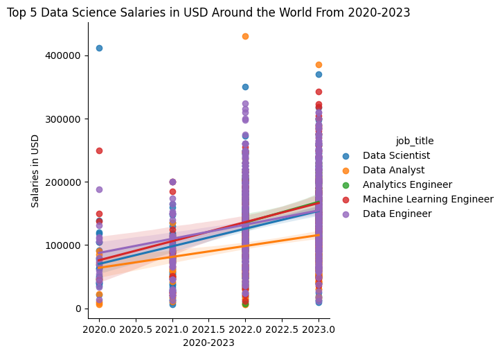

```python
#top 5 Data Science jobs between 2020-2021
fig = plt.figure(figsize = (10,5))
#creating plot
sns.lmplot(x = 'work_year', y = 'salary_in_usd', hue = 'job_title', data = data2)
plt.xlabel("2020-2023")
plt.ylabel("Salaries in USD")
plt.title("Top 5 Data Science Salaries in USD Around the World From 2020-2023")
```

As future computer and data scientists, we knew prior to looking at this dataset the the US consistently has the highest salaries when it comes to tech careers. This data set solidified that for us. Becuase of this we want to compare the salaries in different locations to see how big of a difference there is. As you can see in this box and whisker plot below, for data science, the US has a much higher average salary. With Canada falling closely behind. The lowest average is India. We are only comparing the countries that have enough salaries to actually create a box, some countries didn't have enough and were creating straight lines and not boxes. We have made plots for this for different job titles.

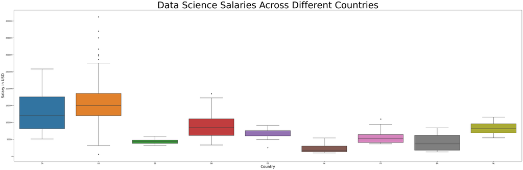

```python
plt.figure(figsize=(50,15))
ds = data2[data2['job_title'] == 'Data Scientist']
countries = ['CA', 'US', 'ES', 'GB',
             'IE', 'DE', 'IN', 'FR',
             'BR', 'LV', 'HJ', 'TR',
             'NL', 'BE', 'AT']
locs = ds[ds.company_location.isin(countries)]
sns.boxplot(data=locs, x='company_location', y='salary_in_usd')
plt.title("Data Science Salaries Across Different Countries", fontdict={'fontsize': 50})
plt.xlabel("Country", fontdict={'fontsize': 20})
plt.ylabel("Salary in USD", fontdict={'fontsize': 20})
plt.show()
```

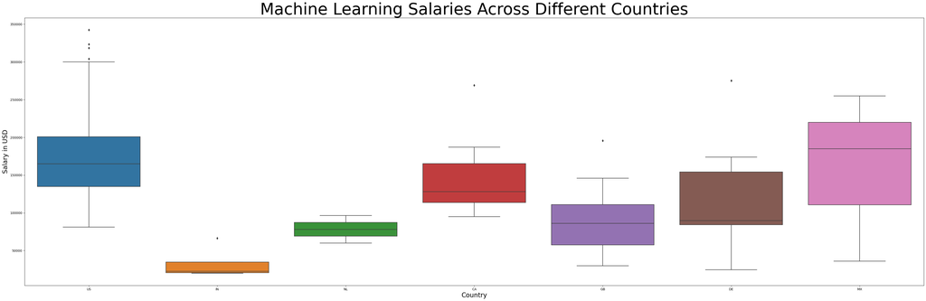

```python
plt.figure(figsize=(50,15))
ds = data2[data2['job_title'] == 'Machine Learning Engineer']
countries = ['US', 'IN', 'NL', 'CA',
             'GB', 'DE', 'MX']
locs = ds[ds.company_location.isin(countries)]
sns.boxplot(data=locs, x='company_location', y='salary_in_usd')
plt.title("Machine Learning Salaries Across Different Countries", fontdict={'fontsize': 50})
plt.xlabel("Country", fontdict={'fontsize': 20})
plt.ylabel("Salary in USD", fontdict={'fontsize': 20})
plt.show()
```

As you can see, the graph below for Analytics Engineering doesn't have many countries to compare data against. This could be because of how closely related analytics engineering is to data engineering and data science, some countries just may not feel the need to have so many different jobs when they can be grouped in one. Over the next decade [this role is expected to grow by about 25%](https://www.indeed.com/career-advice/finding-a-job/what-is-analytical-engineer), while data science is [expected to grow by about 36%](https://www.bls.gov/ooh/math/data-scientists.htm)

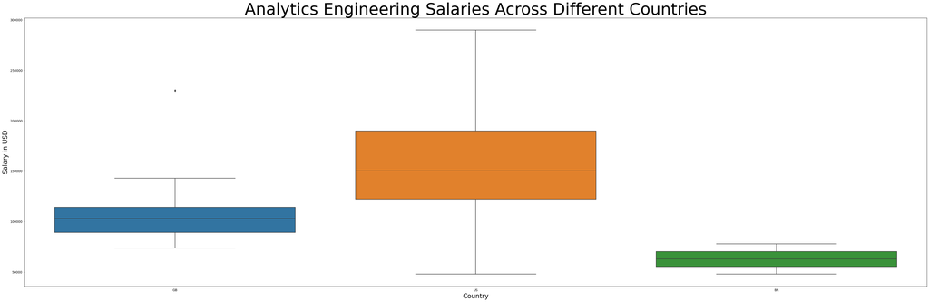

```python
plt.figure(figsize=(50,15))
ds = data2[data2['job_title'] == 'Analytics Engineer']
countries = ['US','GB', 'BR']
locs = ds[ds.company_location.isin(countries)]
sns.boxplot(data=locs, x='company_location', y='salary_in_usd')
plt.title("Analytics Engineering Salaries Across Different Countries", fontdict={'fontsize': 50})
plt.xlabel("Country", fontdict={'fontsize': 20})
plt.ylabel("Salary in USD", fontdict={'fontsize': 20})
plt.show()
```

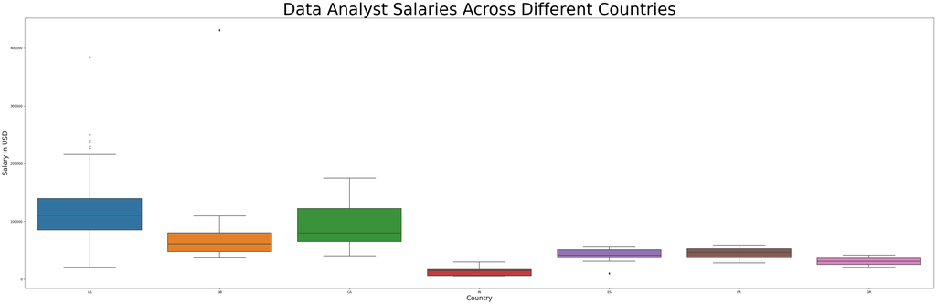

```python
plt.figure(figsize=(50,15))
ds = data2[data2['job_title'] == 'Data Analyst']
countries = ['US','GB', 'CA',
             'IN', 'ES', 'AJ',
             'FR', 'GR']
locs = ds[ds.company_location.isin(countries)]
sns.boxplot(data=locs, x='company_location', y='salary_in_usd')
plt.title("Data Analyst Salaries Across Different Countries", fontdict={'fontsize': 50})
plt.xlabel("Country", fontdict={'fontsize': 20})
plt.ylabel("Salary in USD", fontdict={'fontsize': 20})
plt.show()
```

In the graph below, we can see that not only are there more countries that have a lot of data engineering jobs, but the average salaries are also higher. In this role, the US and Canada have about the same average salaries at around 150,000 U.S. dollars.

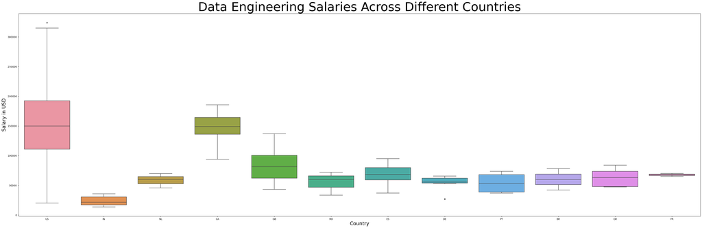

```python
plt.figure(figsize=(50,15))
ds = data2[data2['job_title'] == 'Data Engineer']
countries = ['US','IN', 'NL',
             'CA', 'GB', 'MX',
             'ES', 'DE', 'PT',
             'BR', 'GR', 'FR']
locs = ds[ds.company_location.isin(countries)]
sns.boxplot(data=locs, x='company_location', y='salary_in_usd')
plt.title("Data Engineering Salaries Across Different Countries", fontdict={'fontsize': 50})
plt.xlabel("Country", fontdict={'fontsize': 20})
plt.ylabel("Salary in USD", fontdict={'fontsize': 20})
plt.show()
```

## **8.4 Salary vs. Country for each Job Title based on Company Size**

Here we are looking at the effects that a company's size has on the salaries of its employees. In the graph below we have bar plots for each country with each bar representing the company size. For this plot we are focusing on Data Science Salaries, the distribution is pretty similar across different job titles. It's very interesting to see that medium sized companies are pretty consistently paying more throughout. You would think that a larger company would have more money to give to their employees. However, research has shown that data scientists start bigger at smaller companies. Whereas many job titles show dramatic increases with company size, [data scientists at smaller companies earn only slightly less at smaller companies than they do at large companies.](https://www.comparably.com/blog/public-or-private-large-or-small-how-much-you-can-earn-in-tech/) And though medium-sized companies employ the fewest workers nationwide, [tech workers prefer this size by 44%.](https://venturebeat.com/business/startups-or-giants-does-size-matter-when-tech-workers-choose-jobs/)

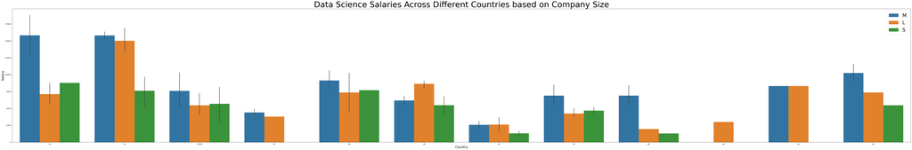

```python
plt.figure(figsize=(100,15))
ds = data2[data2['job_title'] == 'Data Scientist']
sns.barplot(data=ds, x='company_location', y='salary_in_usd', hue='company_size')
plt.legend(prop = { "size": 30 }, loc ="upper right")
plt.title("Data Science Salaries Across Different Countries based on Company Size", fontdict={'fontsize': 50})
plt.xlabel("Country", fontdict={'fontsize': 20})
plt.ylabel("Salary", fontdict={'fontsize': 20})
plt.show()
```

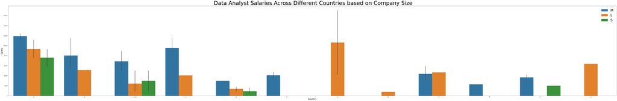

```python
plt.figure(figsize=(100,15))
ds = data2[data2['job_title'] == 'Data Analyst']
sns.barplot(data=ds, x='company_location', y='salary_in_usd', hue='company_size')
plt.legend(prop = { "size": 30 }, loc ="upper right")
plt.title(" Data Analyst Salaries Across Different Countries based on Company Size", fontdict={'fontsize': 50})
plt.xlabel("Country", fontdict={'fontsize': 20})
plt.ylabel("Salary", fontdict={'fontsize': 20})
plt.show()
```

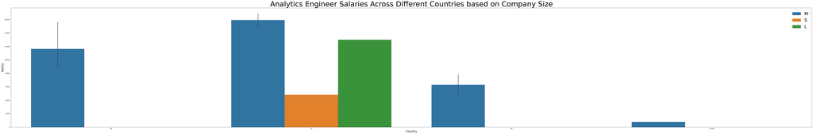

```python
plt.figure(figsize=(100,15))
ds = data2[data2['job_title'] == 'Analytics Engineer']
sns.barplot(data=ds, x='company_location', y='salary_in_usd', hue='company_size')
plt.legend(prop = { "size": 30 }, loc ="upper right")
plt.title("Analytics Engineer Salaries Across Different Countries based on Company Size", fontdict={'fontsize': 50})
plt.xlabel("Country", fontdict={'fontsize': 20})
plt.ylabel("Salary", fontdict={'fontsize': 20})
plt.show()
```

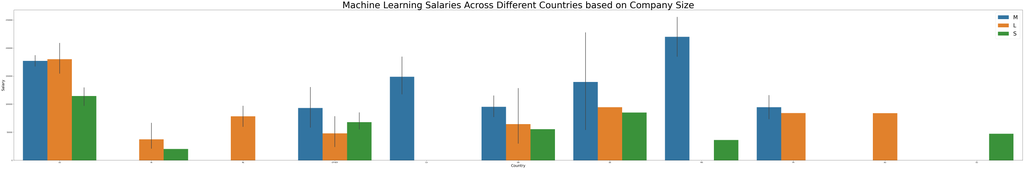

```python
plt.figure(figsize=(100,15))
ds = data2[data2['job_title'] == 'Machine Learning Engineer']
sns.barplot(data=ds, x='company_location', y='salary_in_usd', hue='company_size')
plt.legend(prop = { "size": 30 }, loc ="upper right")
plt.title("Machine Learning Salaries Across Different Countries based on Company Size", fontdict={'fontsize': 50})
plt.xlabel("Country", fontdict={'fontsize': 20})
plt.ylabel("Salary", fontdict={'fontsize': 20})
plt.show()
```

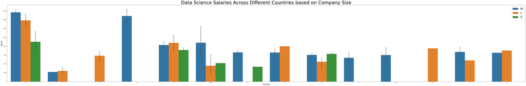

```python
plt.figure(figsize=(100,15))
ds = data2[data2['job_title'] == 'Data Engineer']
sns.barplot(data=ds, x='company_location', y='salary_in_usd', hue='company_size')
plt.legend(prop = { "size": 30 }, loc ="upper right")
plt.title("Data Science Salaries Across Different Countries based on Company Size", fontdict={'fontsize': 50})
plt.xlabel("Country", fontdict={'fontsize': 20})
plt.ylabel("Salary", fontdict={'fontsize': 20})
plt.show()
```

## **8.5 Salary vs. Year for Data Science Based on Experience Level**

In the graphs below we are comparing data science salaries based on experience levels. The distribution is pretty much as expected, with executives making the most and entry levels making the least. There’s a pretty large jump in salary for executives between 2022 and 2023. Between October 2021 and October 2022, [there was a 26% drop in data science job postings.](https://www.interviewquery.com/p/data-science-job-market-disappearing) [And then in 2023, there was a pretty significant increase in job postings](https://intellipaat.com/blog/scope-of-data-science/?US). We also noticed that for Senior level Data Scientists, between 2020 and 2021, there was a steep decline in salary. We believe that this is due to the aftermaths of COVID-19 and how much it affected so many companies and industries, including tech.

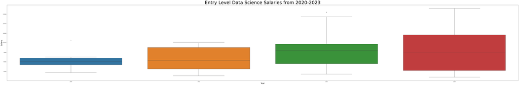

```python
#Entry Level
plt.figure(figsize=(100,15))
ds = data2[data2['job_title'] == 'Data Scientist']
ds_entry = ds[ds['experience_level']=='EN']
sns.boxplot(data=ds_entry, x='work_year', y='salary_in_usd')
plt.title("Entry Level Data Science Salaries from 2020-2023", fontdict={'fontsize': 50})
plt.xlabel("Year", fontdict={'fontsize': 20})
plt.ylabel("Salary", fontdict={'fontsize': 20})
plt.show()
```

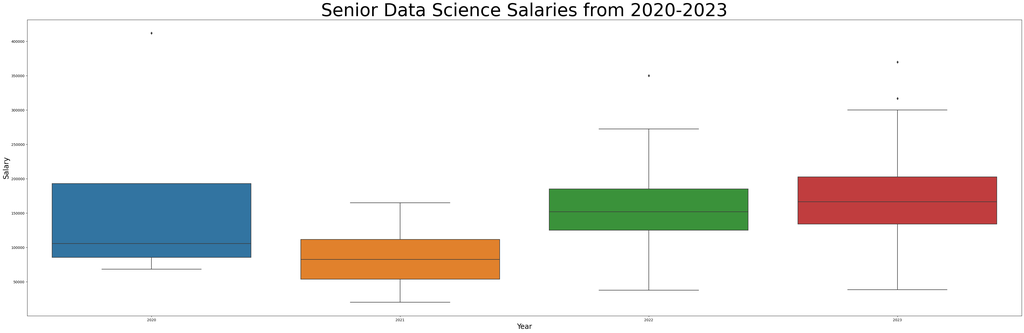

```python
#Senior
plt.figure(figsize=(50,15))
ds = data2[data2['job_title'] == 'Data Scientist']
ds_senior = ds[ds['experience_level']=='SE']
sns.boxplot(data=ds_senior, x='work_year', y='salary_in_usd')
plt.title("Senior Data Science Salaries from 2020-2023", fontdict={'fontsize': 50})
plt.xlabel("Year", fontdict={'fontsize': 20})
plt.ylabel("Salary", fontdict={'fontsize': 20})
plt.show()
```

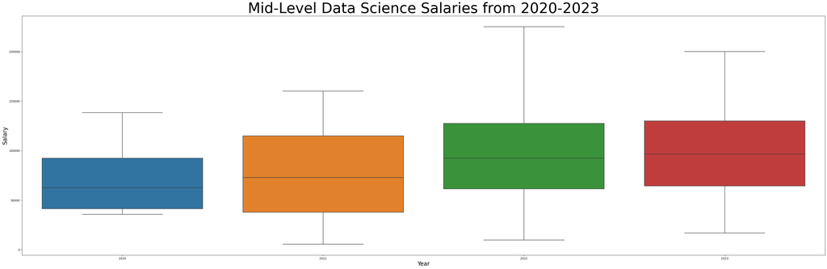

```python
#Mid-Level
plt.figure(figsize=(50,15))
ds = data2[data2['job_title'] == 'Data Scientist']
ds_senior = ds[ds['experience_level']=='MI']
sns.boxplot(data=ds_senior, x='work_year', y='salary_in_usd')
plt.title("Mid-Level Data Science Salaries from 2020-2023", fontdict={'fontsize': 50})
plt.xlabel("Year", fontdict={'fontsize': 20})
plt.ylabel("Salary", fontdict={'fontsize': 20})
plt.show()
```

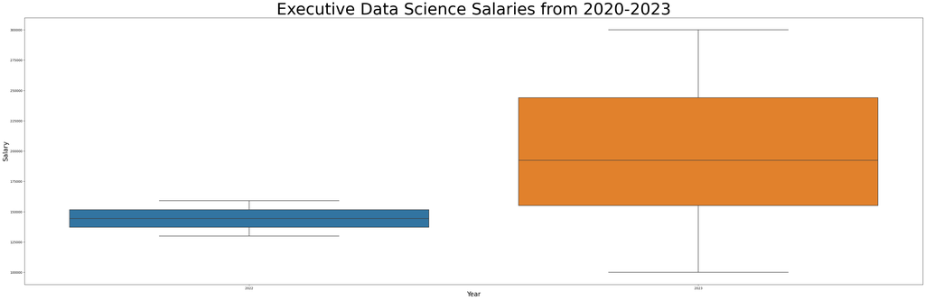

```python
# Executive
plt.figure(figsize=(50,15))
ds = data2[data2['job_title'] == 'Data Scientist']
ds_senior = ds[ds['experience_level']=='EX']
sns.boxplot(data=ds_senior, x='work_year', y='salary_in_usd')
plt.title("Executive Data Science Salaries from 2020-2023", fontdict={'fontsize': 50})
plt.xlabel("Year", fontdict={'fontsize': 20})
plt.ylabel("Salary", fontdict={'fontsize': 20})
plt.show()
```

## **9. LINEAR REGRESSION MODEL**

After cleaning, evaluating and summarizing our data. We decided to build a linear regression model focused on the company location since it seems to be one of the very important features that affect our data. In the folllowing lines of code, we will predict the value of the salary based on the 5 countries.

### **How did we pick the 5 countries?**

Our goal was to find countries that fall in different categories. Some that are more popular, some that fall in the middle, and some that are lower. When we looked at the data set, we noticed that the United States and Canada had the highest popularity and France and India were somewhat in the middle and Mexico was at the top5countries lowest position. We made sure to diversify our independent variable to have a more interesting analysis just like the one in project 3.

```python
countries =['US', 'CA',
            'IN', 'FR', 'MX']
data3 = data1[data1.company_location.isin(countries)]
data3.head()
```

|  | work_year | experience_level | employment_type | job_title | salary_in_usd | remote_ratio | company_location | company_size |
| --- | --- | --- | --- | --- | --- | --- | --- | --- |
| 1 | 2023 | MI | CT | ML Engineer | 30000 | 100 | US | S |
| 2 | 2023 | MI | CT | ML Engineer | 25500 | 100 | US | S |
| 3 | 2023 | SE | FT | Data Scientist | 175000 | 100 | CA | M |
| 4 | 2023 | SE | FT | Data Scientist | 120000 | 100 | CA | M |
| 5 | 2023 | SE | FT | Applied Scientist | 222200 | 0 | US | L |

```python
res1 = smf.ols(formula="salary_in_usd ~ company_location: work_year", data = data3).fit()
print(res1.summary())
```

```
                            OLS Regression Results
==============================================================================
Dep. Variable:          salary_in_usd   R-squared:                       0.140
Model:                            OLS   Adj. R-squared:                  0.138
Method:                 Least Squares   F-statistic:                     68.54
Date:                Wed, 10 May 2023   Prob (F-statistic):           1.53e-66
Time:                        23:33:47   Log-Likelihood:                -26186.
No. Observations:                2112   AIC:                         5.238e+04
Df Residuals:                    2106   BIC:                         5.242e+04
Df Model:                           5
Covariance Type:            nonrobust
==================================================================================================
                                     coef    std err          t      P>|t|      [0.025      0.975]
--------------------------------------------------------------------------------------------------
Intercept                      -1.953e+07   3.79e+06     -5.153      0.000    -2.7e+07   -1.21e+07
company_location[CA]:work_year  9724.3639   1874.558      5.188      0.000    6048.185    1.34e+04
company_location[FR]:work_year  9695.8346   1875.168      5.171      0.000    6018.460    1.34e+04
company_location[IN]:work_year  9677.4767   1875.064      5.161      0.000    6000.305    1.34e+04
company_location[MX]:work_year  9707.4933   1874.512      5.179      0.000    6031.405    1.34e+04
company_location[US]:work_year  9734.2617   1874.386      5.193      0.000    6058.421    1.34e+04
==============================================================================
Omnibus:                      295.239   Durbin-Watson:                   1.852
Prob(Omnibus):                  0.000   Jarque-Bera (JB):              557.454
Skew:                           0.874   Prob(JB):                    8.92e-122
Kurtosis:                       4.811   Cond. No.                     5.73e+06
==============================================================================

Notes:
[1] Standard Errors assume that the covariance matrix of the errors is correctly specified.
[2] The condition number is large, 5.73e+06. This might indicate that there are
strong multicollinearity or other numerical problems.
```

## **Conclusion: Analysis of the OLS regression Results**

From this table we can note that, all our independent variables are statistical significant because there p value = 0.000 which is less than a significance leve l of 0.05. We can reject the null hypothesis. We can also see that our all our coefficients are positive, which indicates that as the salaries will tend to increase as time goes by.

```python
y_intercept1 = res1.params.Intercept
res1.params
```

```
Intercept                        -1.953431e+07
company_location[CA]:work_year    9.724364e+03
company_location[FR]:work_year    9.695835e+03
company_location[IN]:work_year    9.677477e+03
company_location[MX]:work_year    9.707493e+03
company_location[US]:work_year    9.734262e+03
dtype: float64
```

```python
# Create a dictionary of the slope
mappingSlope = {
    "CA":9.724364e+03,
    "FR": 9.695835e+03,
    "IN": 9.677477e+03,
    "MX": 9.707493e+03,
    "US":  9.734262e+03

}
y_intercept1=  res1.params.Intercept

#create new column representing the salary predictions
lifeExp_pred1 = []
interaction_residuals = []
for a, x, c in zip(data3['salary_in_usd'], data3['work_year'], data3['company_location']):
    # getting a single prediction
    lifeExp_pred_i = x * mappingSlope[c]  + y_intercept1
    #list of life expectation prediction
    lifeExp_pred1.append(lifeExp_pred_i)

    # lifeExp_i - lifeExp_Pred_i = mx + b -> x = year
    interaction_residuals.append(a - lifeExp_pred_i)

    #adding 2 new columns to our data
    # 1 -> residual and life_prediction

data3['interaction_residuals'] = interaction_residuals
data3['salary_pred1'] = lifeExp_pred1
data3
```

|  | work_year | experience_level | employment_type | job_title | salary_in_usd | remote_ratio | company_location | company_size | interaction_residuals | salary_pred1 |
| --- | --- | --- | --- | --- | --- | --- | --- | --- | --- | --- |
| 1 | 2023 | MI | CT | ML Engineer | 30000 | 100 | US | S | -128097.931974 | 158097.931974 |
| 2 | 2023 | MI | CT | ML Engineer | 25500 | 100 | US | S | -132597.931974 | 158097.931974 |
| 3 | 2023 | SE | FT | Data Scientist | 175000 | 100 | CA | M | 36925.722026 | 138074.277974 |
| 4 | 2023 | SE | FT | Data Scientist | 120000 | 100 | CA | M | -18074.277974 | 138074.277974 |
| 5 | 2023 | SE | FT | Applied Scientist | 222200 | 0 | US | L | 64102.068026 | 158097.931974 |
| ... | ... | ... | ... | ... | ... | ... | ... | ... | ... | ... |
| 3750 | 2020 | SE | FT | Data Scientist | 412000 | 100 | US | L | 283104.854026 | 128895.145974 |
| 3751 | 2021 | MI | FT | Principal Data Scientist | 151000 | 100 | US | L | 12370.592026 | 138629.407974 |
| 3752 | 2020 | EN | FT | Data Scientist | 105000 | 100 | US | S | -23895.145974 | 128895.145974 |
| 3753 | 2020 | EN | CT | Business Data Analyst | 100000 | 100 | US | L | -28895.145974 | 128895.145974 |
| 3754 | 2021 | SE | FT | Data Science Manager | 94665 | 50 | IN | L | 70798.077026 | 23866.922974 |

2112 rows × 10 columns

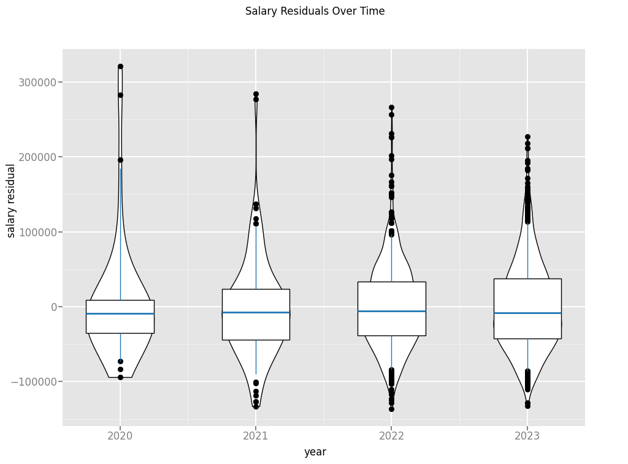

```python
# Make violin plot like in exercise 2
ggplot(aes(x='work_year', y='interaction_residuals'), data=data3) +\
    geom_violin()+ \
    labs(title="Salary Residuals Over Time",
         x = "year",
         y = "salary residual")+ geom_boxplot(width = 0.5) +\
    coord_flip()
```

```
[Text(0.5, 1.0, 'Salary Interaction Residuals Over Time Based on Company Size')]
```

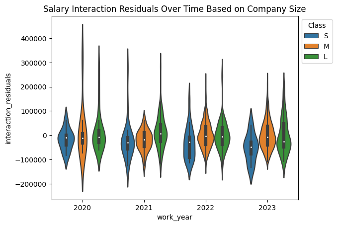

```python
p = sns.violinplot(data=data3,  x='work_year', y='interaction_residuals', hue='company_size')
p.legend(title='Class', bbox_to_anchor=(1, 1), loc='upper left')
p.set(title = 'Salary Interaction Residuals Over Time Based on Company Size')
```